# Cancer Death Rate in US

July 26, 2018

## Overview

The application is an interactive tool that provides:

- Cancer related death rate (deaths per 100,000 population) in US from 1999 and 2014.
- Graphical interaction to display the death rate and predict it for years after 2014. (Linear Regression Model)

**Data source:** CDC (Center for Disease Control and Prevention) https://wonder.cdc.gov/wonder/help/CancerMort-v2014.html#Age-Adjusted.

**App CODE:** https://github.com/Norberto11/data_product_W4/tree/master

## Data set

Data frame with 16 rows and 52 columns.

```r
head(dataset[,c(1:8)],10)
```

```
   year Alabama Alaska Arizona Arkansas California Colorado Connecticut
1  1999    9506    633    9006     6137      53064     5862        7054
2  2000    9807    704    9073     6090      53155     5922        7065
3  2001    9801    689    9142     6091      53923     6145        7093
4  2002    9698    715    9359     6282      54143     6384        7163
5  2003    9812    735    9625     6119      54319     6417        7130
6  2004    9756    728    9618     6304      53700     6196        7174
7  2005    9913    732    9820     6361      54729     6395        7052
8  2006    9899    790    9918     6177      54140     6550        7044
9  2007   10025    839   10133     6388      55011     6617        6827
10 2008   10182    867   10081     6526      54686     6719        6830
```

## Inputs and Outputs

Inputs

- **State** (List of all US states)
- **Year for prediction** (List from 2015 to 2025)
- **Year for all states** graph (List from 1999 to 2014)

Outputs

- Death rate trend **per state** from 1999 to 2014
- **Prediction** death rate for 100,000 population **for the selected state**
- Death rate **for all states** for a selected year

## Graphical Results

Below the main panel and one of the two types of graphs generated by the application. The graph shows the death rate for the state of Alabama and a linear regression model with 95% confident interval shaded area. At the bottom the prediction for the selected year input.

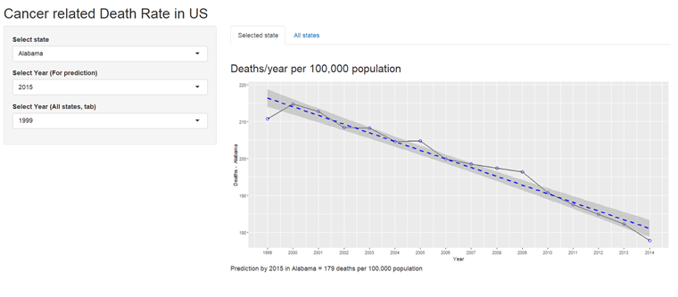